# Homework 5

Samikshya

2022-10-31

Chapter 7: More on Confidence Interval ## Question 7.1

1. This is False because the probability that a cow produces on average between the given range is either 0 or 1. It either produces the milk within the given range (22-30)kg/day or it does not.
2. False because we cannot apply the confidence interval to every sample. It just means that 95% of the sample will include within its confidence interval the true population mean.
3. This is false because we cannot claim that each sample will include the mean of the population 95% of the time. What we can say is 95% of the confidence intervals generated by each sample will contain the true mean.
4. False. IT necessarily isnot within the interval.
5. False, we can claim that for 95% of the sample collected,95% of these sample distribution intervals will include the true population mean.

```r
library(tidyverse)
```

```r
library(ggplot2)
library(resampledata)
library(dplyr)
```

## Question 7.4

1. Given sample has a t distribution so we can use the t distribution table. Here the n given determines the degrees of freedom that will determine the t confidence interval of the 90%.

```r
# To find the quantile q of 90% with n = 5,15,30,100:
#The degrees of freedom is n-1 so df would be 4,14,29,99 respectively
df4 <- qt(0.95, 4)
df14 <- qt(0.95, 14)
df29 <- qt(0.95, 29)
df99 <- qt(0.95, 99)

print(df4)
```

```
## [1] 2.131847
```

```r
print(df14)
```

```
## [1] 1.76131
```

```r
print(df29)
```

```
## [1] 1.699127
```

```r
print(df99)
```

```
## [1] 1.660391
```

```r
abs(qnorm(0.95))
```

```
## [1] 1.644854
```

```r
t.score90 = qt(0.95, df=14)
t.score95 = qt(p=0.975, df=14)
t.score99 = qt(p=0.995, df=14)

t.score90
```

```
## [1] 1.76131
```

```r
t.score95
```

```
## [1] 2.144787
```

```r
t.score99
```

```
## [1] 2.976843
```

We know that the formula for margin of error is q(sd/sqr(n)). At given state, q is 1.86 for 95% percentile. So if we want to half this, the probability is 97.5. Now if we want to reduce the MOE than our formula becomes 1.96(sd/sqr(n2)) = 1.96*(sd/sqr(n1))/2 From algebraic calculation, sqr(n2) = 2* sqr (n1), Squaring both sides, we get, n2 = 4 times n1.we can conclude that the new sample needs to be at least 4 times the original sample.

```r
n <- 20
xbar <- 18.05
sd <- 5
percentage <- 0.90
zScore <- qt(percentage, n -1)
zScore
```

```
## [1] 1.327728
```

```r
Lowerlimit <- xbar - (zScore* ((sd/sqrt(n))))
Lowerlimit
```

```
## [1] 16.56555
```

```r
Upperlimit <- xbar + (zScore* ((sd/sqrt(n))))
Upperlimit
```

```
## [1] 19.53445
```

From the calculation above, the 90% confidence interval for the mean amount of sugar in half cup serving is 16.56, 19.53)

## Question 7.7

n = 100, mean = 120 hours, SD = 12. Moderate skewness: so we use T distribution. To find, one sided lower t confidence Confidence interval = 95%

```r
n <- 100
xbar <- 120
sd <- 12
percentage <- 0.95
zScore <- qt(percentage, n -1)
zScore
```

```
## [1] 1.660391
```

```r
Lowerlimit <- xbar - (zScore* ((sd/sqrt(n))))
Lowerlimit
```

```
## [1] 118.0075
```

The lower bound is 118.0075.

##Question 7.11

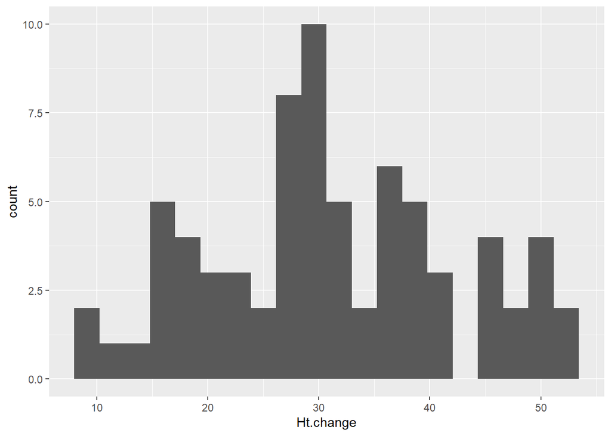

```r
data("Spruce")
ggplot(data = Spruce, mapping = aes(x = Ht.change))+
  geom_histogram(bins = 20)
```

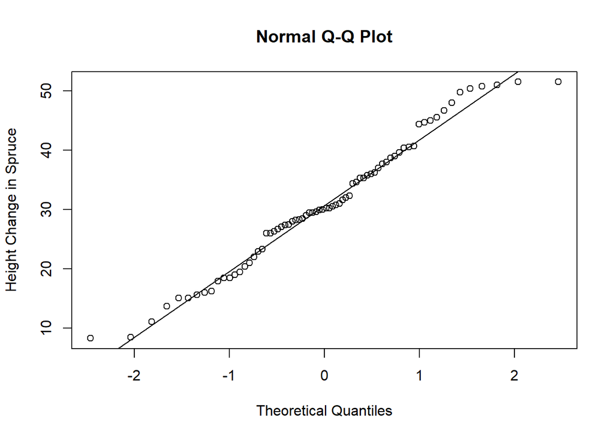

```r
qqnorm(Spruce$Ht.change,
         ylab = "Height Change in Spruce")

qqline(Spruce$Ht.change)
```

```r
t.test(Spruce$Ht.change, conf.level = 0.95)
```

```
##
##  One Sample t-test
##
## data:  Spruce$Ht.change
## t = 23.755, df = 71, p-value < 2.2e-16
## alternative hypothesis: true mean is not equal to 0
## 95 percent confidence interval:
##  28.33685 33.52982
## sample estimates:
## mean of x
##  30.93333
```

The confidence interval is 28.336 and 33.529. Wecan say with 95% confidence that the mean of the Ht, Change will lie within the range of 28.336 and 33.5298.

## Question 7.14

```r
data("Girls2004")
#glimpse(Girls2004)
```

```r
Smokers <- Girls2004 %>%
  filter(Smoker == "Yes")
#glimpse(Smokers)
```

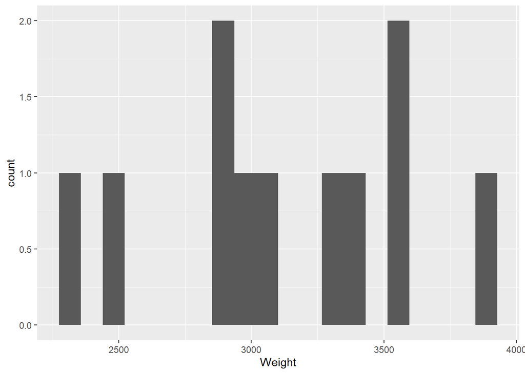

```r
ggplot(data = Smokers, mapping = aes(x = Weight))+
  geom_histogram(bins = 20)
```

[figure not shown]

```r
qqnorm(Smokers$Weight,
         ylab = "Height Change in Spruce")

qqline(Smokers$Weight)
```

The weight is fairly normally distributed.

For non-smokers

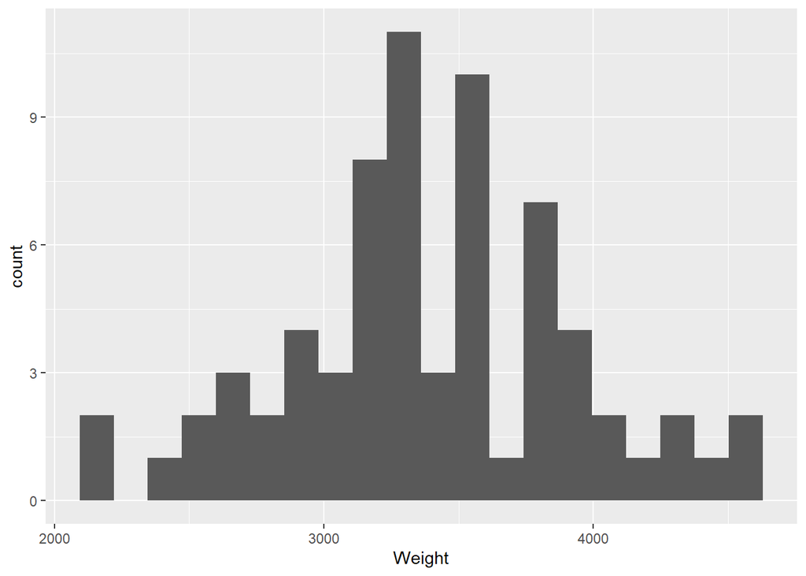

```r
NonSmokers <- Girls2004 %>%
  filter(Smoker == "No")
ggplot(data = NonSmokers, mapping = aes(x = Weight))+
  geom_histogram(bins = 20)
```

[figure not shown]

```r
qqnorm(NonSmokers$Weight,
         ylab = "Height Change in Spruce")

qqline(NonSmokers$Weight)
```

The distribution of the non smokers is normally distributed with long right tail towards the end.

Counting the number of smokers and nonsmokers:

```r
Nsmokers = nrow(Smokers)
Nnonsmokers = nrow(NonSmokers)
Nsmokers
```

```
## [1] 11
```

```r
Nnonsmokers
```

```
## [1] 69
```

There is discrepancy in numbers of sample between two groups as numbers of smokers is 11 and no of non smokers is 69.

Conducting mean height difference with the babies born to smokers and non smokers with lower bound:

```r
Weight_difference <- t.test(Weight~Smoker, data = Girls2004,alt = "greater",conf.level = 0.95 )
Weight_difference
```

```
##
##  Welch Two Sample t-test
##
## data:  Weight by Smoker
## t = 1.8552, df = 14.35, p-value = 0.04211
## alternative hypothesis: true difference in means between group No and group Yes is greater than 0
## 95 percent confidence interval:
##  14.99055      Inf
## sample estimates:
##  mean in group No mean in group Yes
##          3401.580          3114.636
```

## Question 7.15

```r
data("Spruce")
#glimpse(Spruce)
```

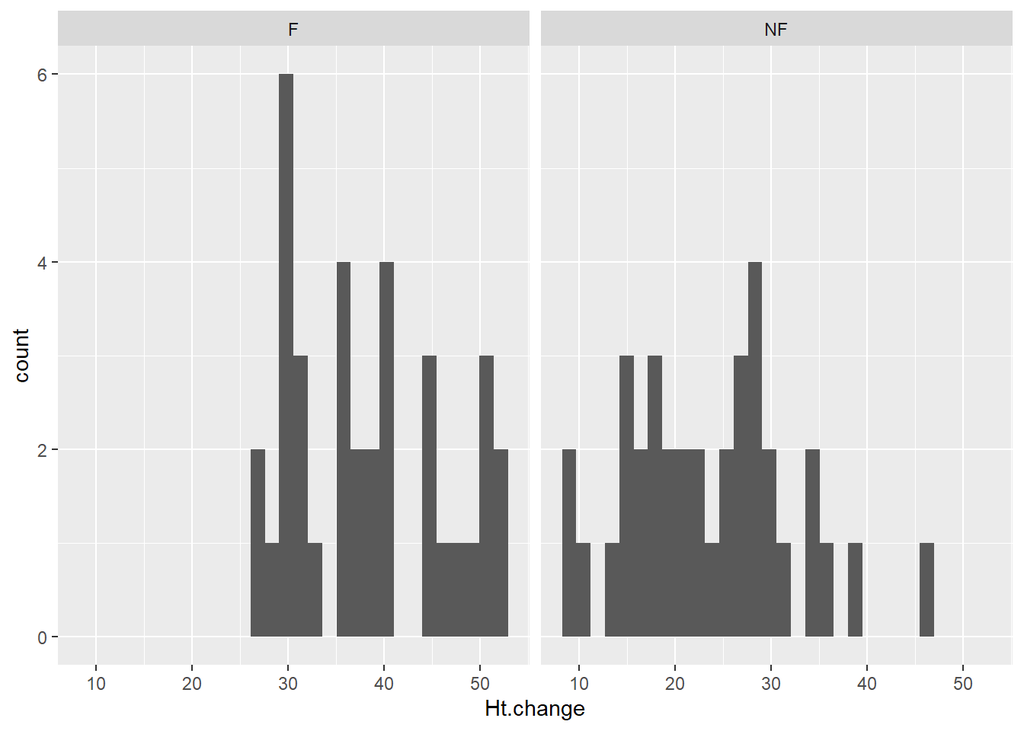

```r
ggplot(data = Spruce, mapping = aes(x = Ht.change))+
  geom_histogram()+
  facet_wrap(~Fertilizer)
```

Qqplor for Weights where fertilizer is used

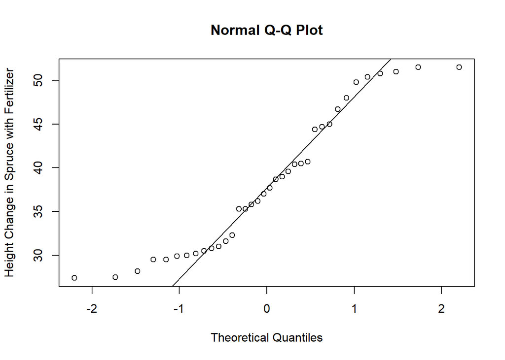

```r
data("Spruce")
#glimpse(Spruce)
qqnorm(Spruce$Ht.change[Spruce$Fertilizer =="F"],
         ylab = "Height Change in Spruce with Fertilizer")
qqline(Spruce$Ht.change[Spruce$Fertilizer =="F"])
```

The qq plot for fertilized sample show that the Height change for fertilized plants shows fairly normal distribution with tails in the end. The graph also shows that the data set is granular(gap in the values). This can also be observed in the histogram.

qq plot for non fertilized:

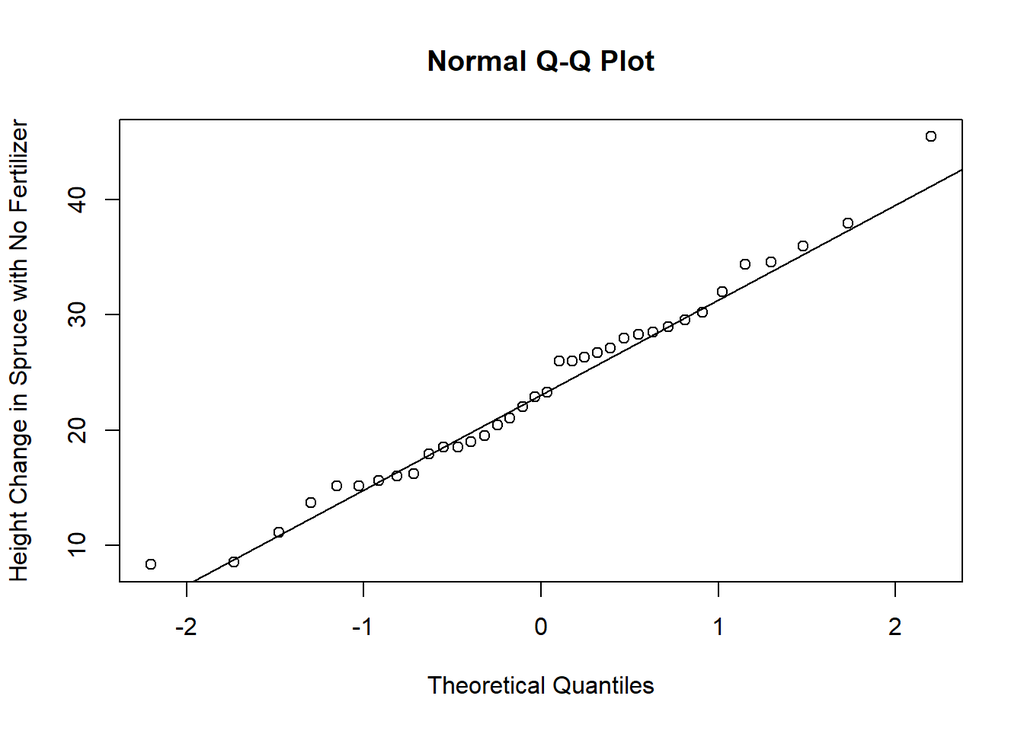

```r
qqnorm(Spruce$Ht.change[Spruce$Fertilizer =="NF"],
         ylab = "Height Change in Spruce with No Fertilizer")
qqline(Spruce$Ht.change[Spruce$Fertilizer =="NF"])
```

The non fertilized pot also show similar pattern to the fertilzied pot in terms for data gap. However, the tail seems not to sway awat from the qq line compared to the fertilized ones.

```r
Height_difference <- t.test((Spruce$Ht.change[Spruce$Fertilizer =="F"]),(Spruce$Ht.change[Spruce$Fertilizer =="NF"]), alt = "greater",conf.level = 0.95 )
Height_difference
```

```
##
##  Welch Two Sample t-test
##
## data:  (Spruce$Ht.change[Spruce$Fertilizer == "F"]) and (Spruce$Ht.change[Spruce$Fertilizer == "NF"])
## t = 7.5586, df = 69.697, p-value = 6.068e-11
## alternative hypothesis: true difference in means is greater than 0
## 95 percent confidence interval:
##  11.46664      Inf
## sample estimates:
## mean of x mean of y
##  38.28889  23.57778
```

The lower bound for the confidence interval of the height difference between fertilized and non fertilized is 11.466.We are 95% confident that the difference in height between fertilized and non fertilized is at least 11.47.

If it is lower t confidence, we use greater.

##Question 7.21

#For exponential distribution: #For n is 10

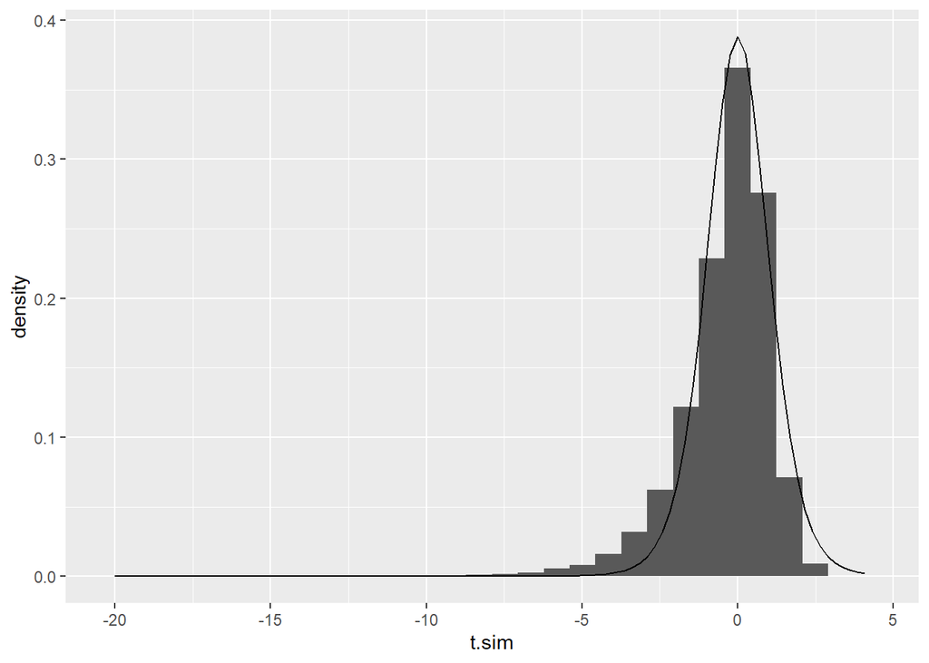

```r
n <- 10
N <- 10^4
t.sim <- numeric(N)

for (i in 1: N)
{
  x<- rexp(n,.2)

  t.sim[i] <- (mean(x) - 5)/(sd(x)/sqrt(n))
}

ggplot(data = tibble(t.sim), mapping = aes(x = t.sim))+
  geom_histogram(mapping = aes(y = ..density..))+
  stat_function(fun = dt, args = list(df = n-1))
```

#For n= 50

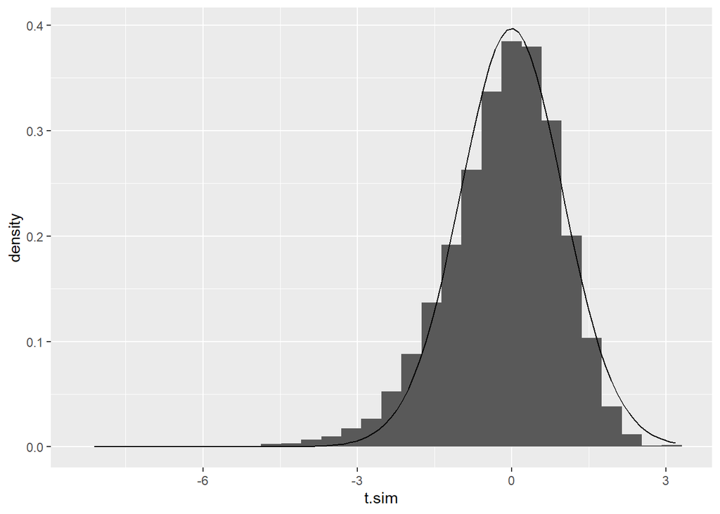

```r
n <- 50
N <- 10^4
t.sim <- numeric(N)

for (i in 1: N)
{
  x<- rexp(n,.2)

  t.sim[i] <- (mean(x) - 5)/(sd(x)/sqrt(n))
}

ggplot(data = tibble(t.sim), mapping = aes(x = t.sim))+
  geom_histogram(mapping = aes(y = ..density..))+
  stat_function(fun = dt, args = list(df = n-1))
```

#n = 1000

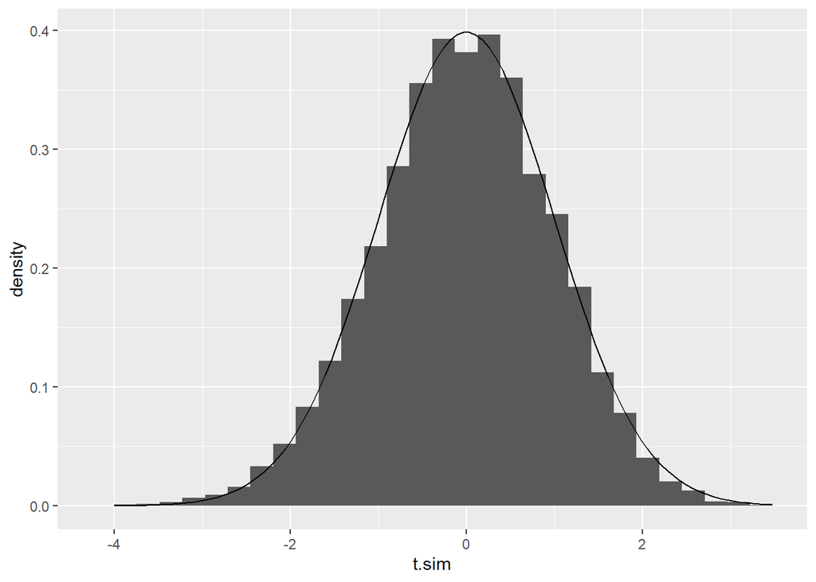

```r
n <- 1000
N <- 10^4
t.sim <- numeric(N)

for (i in 1: N)
{
  x<- rexp(n,.2)

  t.sim[i] <- (mean(x) - 5)/(sd(x)/sqrt(n))
}

ggplot(data = tibble(t.sim), mapping = aes(x = t.sim))+
  geom_histogram(mapping = aes(y = ..density..))+
  stat_function(fun = dt, args = list(df = n-1))
```

When n is small, while the data seems to follow the normal distribution vaguely, especially towards the tail of the t line.The graph and the t distribution donot align towards the end. However, as n increases, we can see that the distribution , it closely follows that the t distribution.

FOr Uniform Distribution:

n= 15:

```r
n <- 15
N <- 10^4
xbar <- 7
uniform.sim <- numeric(N)

for (i in 1: N)
{
  x <- runif(n, min = 4, max = 10)
  uniform.sim[i] <- (mean(x) - xbar)/(sd(x)/sqrt(n))
}
```

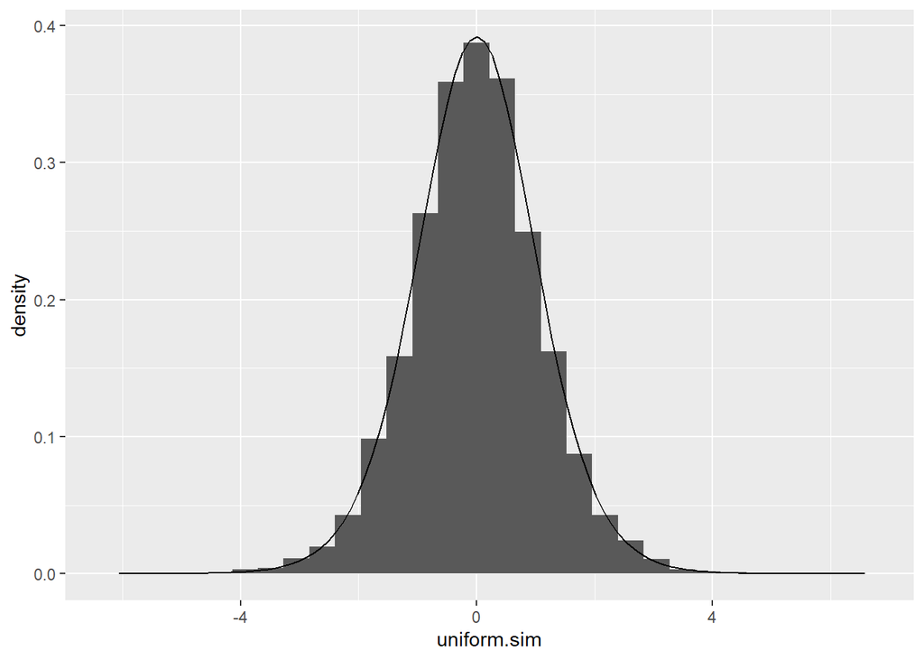

```r
ggplot(data = tibble(uniform.sim), mapping = aes(x = uniform.sim))+
  geom_histogram(mapping = aes(y = ..density..))+
  stat_function(fun = dt, args = list(df = n-1))
```

n= 75

```r
n <- 75
N <- 10^4
xbar <- 7
uniform.sim <- numeric(N)

for (i in 1: N)
{
  x <- runif(n, min = 4, max = 10)
  uniform.sim[i] <- (mean(x) - xbar)/(sd(x)/sqrt(n))
}
```

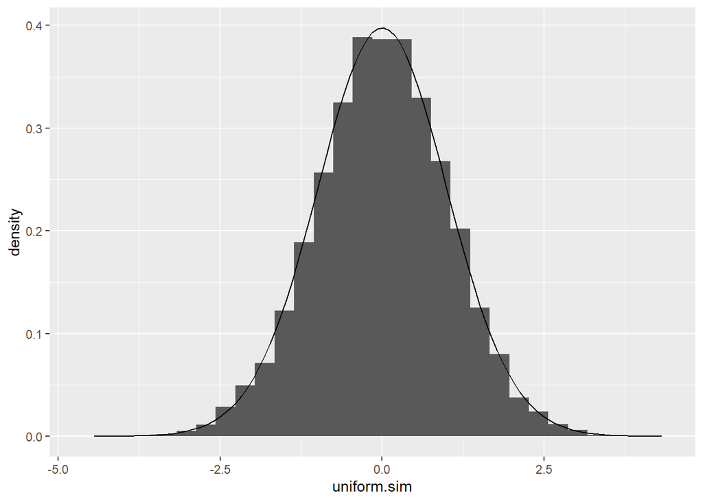

```r
ggplot(data = tibble(uniform.sim), mapping = aes(x = uniform.sim))+
  geom_histogram(mapping = aes(y = ..density..))+
  stat_function(fun = dt, args = list(df = n-1))
```

For n = 500

```r
n <- 500
N <- 10^4
xbar <- 7
uniform.sim <- numeric(N)

for (i in 1: N)
{
  x <- runif(n, min = 4, max = 10)
  uniform.sim[i] <- (mean(x) - xbar)/(sd(x)/sqrt(n))
}
```

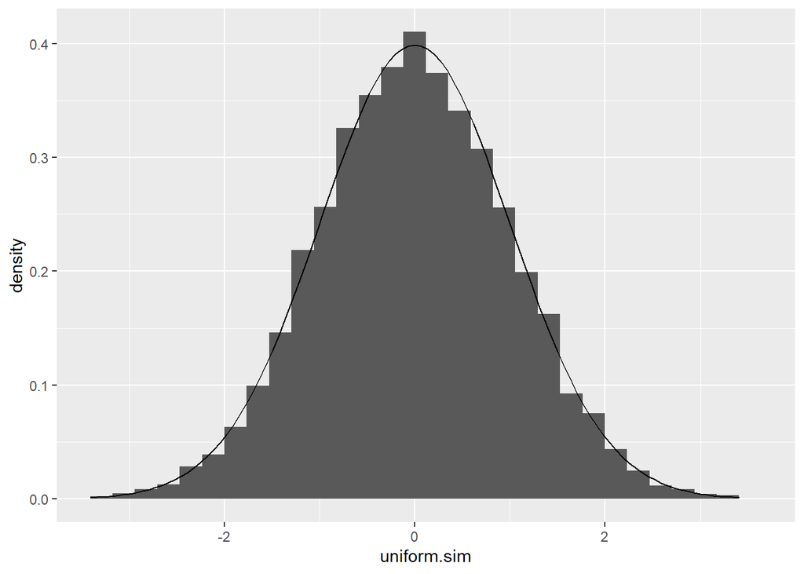

```r
ggplot(data = tibble(uniform.sim), mapping = aes(x = uniform.sim))+
  geom_histogram(mapping = aes(y = ..density..))+
  stat_function(fun = dt, args = list(df = n-1))
```

Similarly, for uniform distribution, the distribution closely starts following the t distribution line as the n increases.

## Question 7.27

n = 700. Break out into hives = 34 of 350 Places hives = 56 of 350

```r
p1.hives = 34/350
p1.hives
```

```
## [1] 0.09714286
```

```r
p2.placebohives = 56/350
p2.placebohives
```

```
## [1] 0.16
```

proportion of those who took drugs and had hives is 0.0971 proportion of those who didnot take drugs(i.e placebo) and had hives is 0.16

```r
prop.test.hives<- prop.test(34,350, conf.level =0.95 )
prop.test.hives
```

```
##
##  1-sample proportions test with continuity correction
##
## data:  34 out of 350, null probability 0.5
## X-squared = 225.6, df = 1, p-value < 2.2e-16
## alternative hypothesis: true p is not equal to 0.5
## 95 percent confidence interval:
##  0.06913692 0.13429260
## sample estimates:
##          p
## 0.09714286
```

With the group that had hives, the confidence interval is 0.0691,0.13429) We can say with 95% confidence that the proportion of student taking the drug who break out in hives is (0.069,0.134), i,e 6.9%,13.4%

```r
prop.test.placebohives<- prop.test(56,350, conf.level =0.95 )
prop.test.placebohives
```

```
##
##  1-sample proportions test with continuity correction
##
## data:  56 out of 350, null probability 0.5
## X-squared = 160.48, df = 1, p-value < 2.2e-16
## alternative hypothesis: true p is not equal to 0.5
## 95 percent confidence interval:
##  0.1240384 0.2036158
## sample estimates:
##    p
## 0.16
```

With the group that had hives, the confidence interval is 0.1240,0.2036) We can say with 95% confidence that the proportion of student who didnot take the drugs and were in placebo drug who break out in hives is (0.124,0.204)i.e (12.4%,20.4%)

3. Yes, the interval overlaps. However, the overlap is only of 0.01 which is really small to really make a conclusion.
4. Confidence interval in proportions of students who break out in hives by using or not using this drug

```r
difference.hives <- prop.test(c(34,56), n= c(350,350), conf.level = 0.95)
difference.hives
```

```
##
##  2-sample test for equality of proportions with continuity correction
##
## data:  c(34, 56) out of c(350, 350)
## X-squared = 5.623, df = 1, p-value = 0.01773
## alternative hypothesis: two.sided
## 95 percent confidence interval:
##  -0.11508783 -0.01062645
## sample estimates:
##     prop 1     prop 2
## 0.09714286 0.16000000
```

The difference in hives rate between those who took the drug and placebo is -0.115-0.0106. Since both the values are negative, we can say that proportion of those who take the drug will experiences hives less by (11.5, 1.06) percent.

5. I believe that the correct approach would be the one in d because here we are conducting a two sample proportion test just on drug effect between two groups, so comparison is occurring between two groups we are interested in. Through this, the skewness of each other could cancel to create a balanced one. The approach on c, because we are making comparison across two different test, we are introducing more variables and maybe more error and skewness without getting new benefits. We have to infer the answers from two different test to create a conclusion.

## Question 7.32

```r
data(MobileAds)
#glimpse(MobileAds)
```

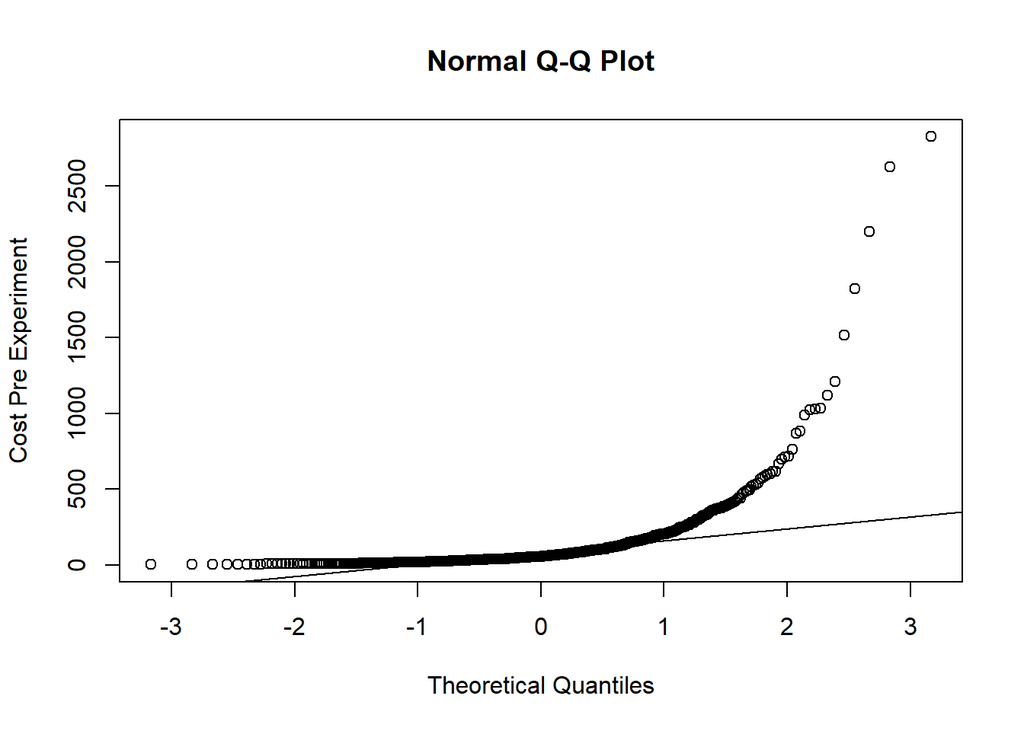

```r
qqnorm(MobileAds$m.cost_pre,
         ylab = "Cost Pre Experiment")
qqline(MobileAds$m.cost_pr)
```

The graph has a long tail to the right that wont follow normal distribution. It looks like a quadratic equation.

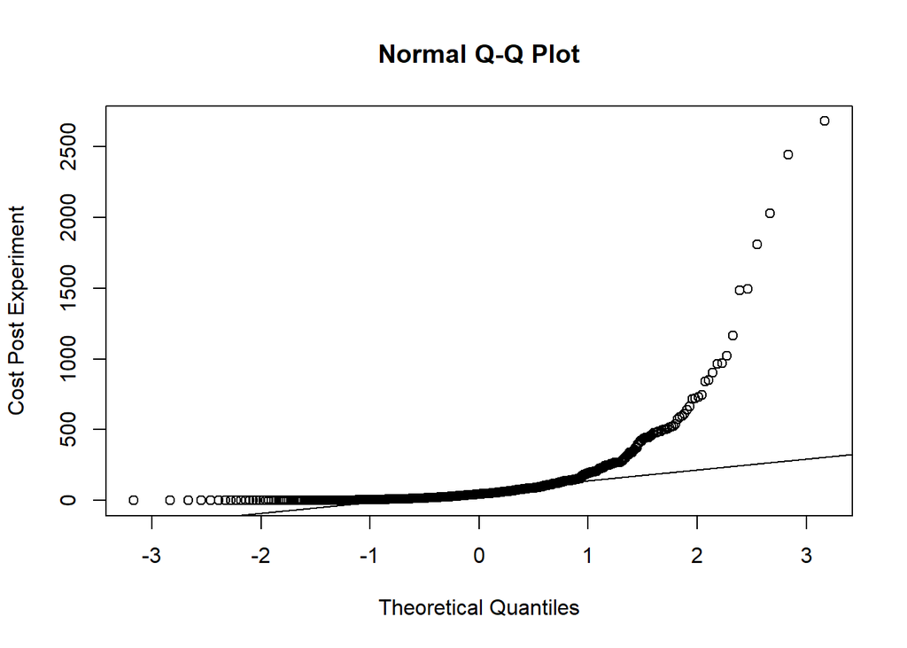

```r
qqnorm(MobileAds$m.cost_post,
         ylab = "Cost Post Experiment")
qqline(MobileAds$m.cost_post)
```

Similar pattern.

b)It is not appropriate to two sample interval because it is a match pais. Both pre and post cost are related to one another and will affect the behavior/outcome of the experiment.

```r
N <- nrow(MobileAds)
diff.cost <- numeric(N)

for (i in 1:N)
{ pre <-MobileAds$m.cost_pre
  post <-MobileAds$m.cost_post
  diff.cost[i] <- pre[i]-post[i]

  }
```

[figure not shown]

```r
qqnorm(diff.cost,
         ylab = "Cost Post Experiment")
qqline(diff.cost)
```

```r
diff<- t.test(diff.cost, conf.level = 0.95)
diff
```

```
##
##  One Sample t-test
##
## data:  diff.cost
## t = 1.9938, df = 654, p-value = 0.04659
## alternative hypothesis: true mean is not equal to 0
## 95 percent confidence interval:
##   0.2086369 27.3349662
## sample estimates:
## mean of x
##   13.7718
```

The 95% confidence interval is (0.2086,27.334). So we can say with 95% confidence that true mean change as a result of the experiment will lie within the range of (0.2086,27.334)

```r
N <- 10^4-1
size.data <- length(diff.cost)
diff.prepostcost <- numeric(N)
for(i in 1:N)
{
  precost <- sample(diff.cost, size = size.data, replace = TRUE)
   diff.prepostcost[i] <- (mean(precost) - mean(diff.cost))/(sd(diff.cost)/sqrt(size.data))
}
```

```r
mean(diff.cost) - quantile(diff.prepostcost, c(0.975,0.025))*sd(diff.cost)/sqrt(size.data)
```

```
##     97.5%      2.5%
##  0.507987 27.460749
```